# Program 3 - Analysis

## Base Setup

This section contains the basic environment set up for this notebook, including imports, constants, and any variable that needs to be easily accessed for changing.

```python
#Import modules
import os
import shutil
import time
import datetime

import pandas as pd
import numpy as np
import matplotlib.pyplot as plt
import seaborn as sns

from sklearn.metrics import confusion_matrix, classification_report
from ipylab import JupyterFrontEnd
```

This is a set of constants used mainly for workspace setup.

`INPUT_DIR`: The relative or absolute path to the base directory containing the outputs from a Program 3 run that needs to be further analyzed.  
`OUTPUT_DIR`: The folder to create inside the INPUT_DIR where output files from this analysis program will be saved.  
`PREDICTION_FILES`: A dictionary whose keys are the three dataloader phases and values are the names of the dataframes containing predictions on every image in each dataloader set.  
`NOTEBOOK_NAME`: The exact name of this notebook, including the file extension. Needed later for programmatic html conversion and copying of the notebook.  
`APP`: JupyterFrontEnd instance that is used to save the notebook programmatically later.

```python
#Define constants
INPUT_DIR = "Output/Small Follicles/ResNet34/Run Final 1/"
OUTPUT_DIR = "Analysis/"
PREDICTION_FILES = {
    'train': "Train_Prediction_Dataframe.parquet",
    'test': "Test_Prediction_Dataframe.parquet",
    'validate': "Validate_Prediction_Dataframe.parquet"
}
NOTEBOOK_NAME = "Program 3 - Analysis Final v3.ipynb"
APP = JupyterFrontEnd() #Needed to save the notebook programmatically later, do not change.
```

These are variables and flags for functions that get used later.

`classes`: A list of the output classes of the model, in order from smallest follicle type to largest, with negative as the first.  
`phases`: A list of the dataloader phases that were used in the model training. Should be the same as the keys of `PREDICTION_FILES`.  
`best_accuracy_epoch`: The number of the epoch that had the best accuracy from training. Check the saved html for the training run being analyzed.  
`best_loss_epoch`: The number of the epoch that had the best loss from training. Check the saved html for the training run being analyzed.  
`save_figs`: A flag to determine whether this program will save any graphs/images it generates.

```python
#Define variables
classes = ["Negative", "Primordial", "Transitional Primordial", "Primary", "Transitional Primary", "Secondary", "Multilayer"]
phases = ['train', 'test', 'validate']

best_accuracy_epoch = 24
best_loss_epoch = 1

save_figs = True
```

### Function Definitions

This section contains all the Functions used by this notebook.

`make_output_dir`: Creates the output directory specified by `OUTPUT_DIR` inside the input directory `INPUT_DIR`.

First, checks if the output directory already exists. If it does, nothing happens. If it doesn't creates the output directory inside the input directory.

```python
def make_output_dir():
    '''Check if the directory specified by OUTPUT_DIR exists inside INPUT_DIR. Create directory if it does not exist.'''
    #Create base output directory if it does not exist
    if not os.path.exists(INPUT_DIR + OUTPUT_DIR):
        os.mkdir(INPUT_DIR + OUTPUT_DIR)
```

## Main Code

This section contains the main code of the program that further analyses the model training that was performed in the main Program 3.

Creates the output directory spcified by `OUTPUT_DIR` inside the input directory specified by `INPUT_DIR`.

```python
#Create the output directory
make_output_dir()
```

Creates a dictionary that stores the percent of correctly predicted images for each follicle type and each dataloader phase.

```python
#Set up dictionary to store data
per_class_accuracies = {}

for phase in phases:
    per_class_accuracies[phase] = {}

    for label in classes:
        per_class_accuracies[phase][label] = []

#Read in and create confusion matrices for each phase of each epoch in INPUT_DIR, then store correct percentages in dictionary
epoch = 0

for directory in sorted(os.listdir(INPUT_DIR))[:-1]:
    if directory == OUTPUT_DIR[:-1]: #If the directory is the output directory
        continue

    for subdirectory in sorted(os.listdir(INPUT_DIR + directory)):
        input_dir = INPUT_DIR + directory + "/" + subdirectory + "/"

        for phase in phases:
            df = pd.read_parquet(input_dir + PREDICTION_FILES[phase])[['True Class', 'Predicted Class']]

            true_classes = df[['True Class']].to_numpy().ravel()
            predicted_classes = df[['Predicted Class']].to_numpy().ravel()

            conf_matrix = confusion_matrix(true_classes, predicted_classes)

            #Create and save classification report
            class_report = classification_report(true_classes, predicted_classes)

            with open(input_dir + phase.capitalize() + "_Classification_Report.txt", "w") as class_report_file:
                class_report_file.write(class_report)

            #Save raw confusion matrix
            pd.DataFrame(conf_matrix).to_csv(input_dir + phase.capitalize() + "_Confusion_Matrix_Raw.csv", index = False)

            conf_matrix = conf_matrix.astype(np.float32) / np.sum(conf_matrix)

            for i in range(len(classes)):
                conf_matrix[i, :] = conf_matrix[i, :] * 100 / np.sum(conf_matrix[i, :])

            #Save percent confusion matrix
            pd.DataFrame(conf_matrix).to_csv(input_dir + phase.capitalize() + "_Confusion_Matrix_Percent.csv", index = False)

            for label, percent in zip(classes, np.diag(conf_matrix)):
                per_class_accuracies[phase][label].append(percent.item())

        epoch += 1
```

Creates and saves a plot showing the prediction accuracies for each follicle class in each dataloader set for every epoch.

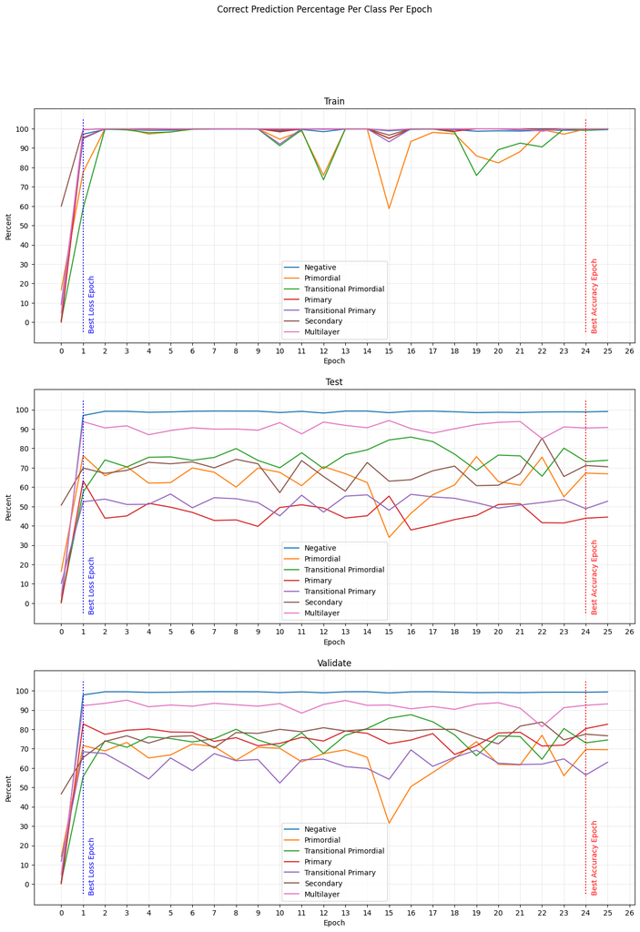

```python
#Plot correct prediction percentages by class per epoch
fig, axes = plt.subplots(3, 1, figsize = (15, 20))

axis = 0

for phase, ax in zip(phases, axes):
    ax.set_xlabel("Epoch")
    ax.set_ylabel("Percent")
    ax.set_yticks(range(0, 101, 10))
    ax.set_xticks(range(0, len(os.listdir(INPUT_DIR)), 1))
    ax.set_title(phase.capitalize())

    for label in classes:
        ax.plot(per_class_accuracies[phase][label], label = label)

    if best_accuracy_epoch == best_loss_epoch:
        ax.vlines(best_accuracy_epoch, ymin = -5, ymax = 105, colors = 'gray', linestyles = ':')
        ax.text(best_accuracy_epoch + 0.25, -5, "Best Loss & Accuracy Epochs", color = 'gray', rotation = 'vertical')
    else:
        ax.vlines([best_loss_epoch, best_accuracy_epoch], ymin = -5, ymax = 105, colors = ['blue', 'red'], linestyles = ':')
        ax.text(best_loss_epoch + 0.25, -5, "Best Loss Epoch", color = 'blue', rotation = 'vertical')
        ax.text(best_accuracy_epoch + 0.25, -5, "Best Accuracy Epoch", color = 'red', rotation = 'vertical')

    ax.legend()
    ax.grid(alpha = 0.25)

fig.suptitle("Correct Prediction Percentage Per Class Per Epoch")

if save_figs:
    file = "Accuracies_Per_Class_Per_Epoch.png"
    plt.savefig(INPUT_DIR + OUTPUT_DIR + file)

plt.show()
```

Create and save a plot of every follicle class accuracy for every epoch that had the highest single-class accuracy per dataloader phase.

```
Highest Accuracies for Each Class per Phase

Train:
  Negative:
    99.9% at Epoch 14
    Full Epoch: ['99.9%', '99.9%', '100.0%', '100.0%', '100.0%', '100.0%', '100.0%']
```

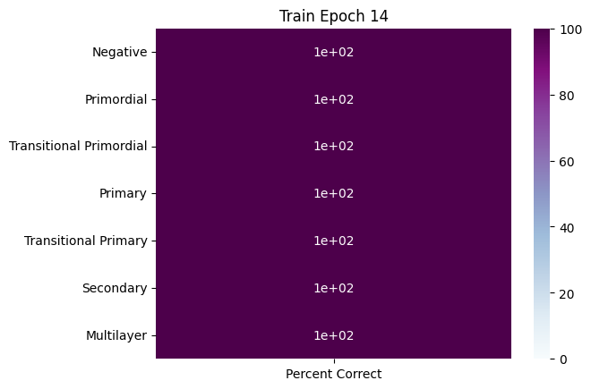

```
  Primordial:
    100.0% at Epoch 8
    Full Epoch: ['99.9%', '100.0%', '100.0%', '100.0%', '100.0%', '100.0%', '100.0%']
```

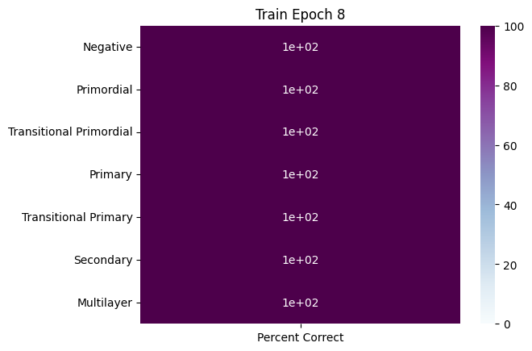

```
  Transitional Primordial:
    100.0% at Epoch 8
    Full Epoch: ['99.9%', '100.0%', '100.0%', '100.0%', '100.0%', '100.0%', '100.0%']
```

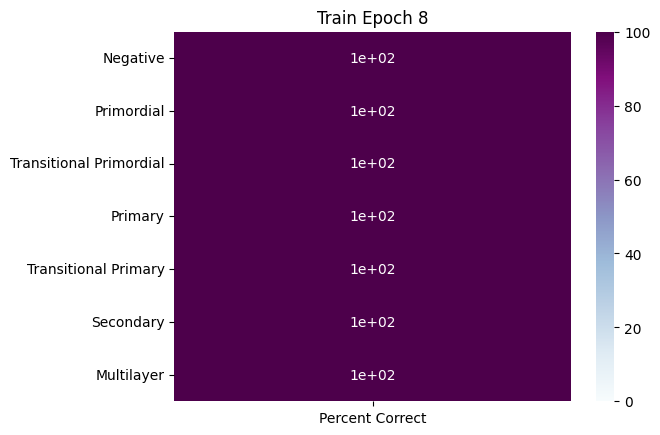

```
  Primary:
    100.0% at Epoch 2
    Full Epoch: ['99.6%', '100.0%', '99.9%', '100.0%', '100.0%', '100.0%', '100.0%']
```

```
  Transitional Primary:
    100.0% at Epoch 2
    Full Epoch: ['99.6%', '100.0%', '99.9%', '100.0%', '100.0%', '100.0%', '100.0%']
```

```
  Secondary:
    100.0% at Epoch 2
    Full Epoch: ['99.6%', '100.0%', '99.9%', '100.0%', '100.0%', '100.0%', '100.0%']
```

```
  Multilayer:
    100.0% at Epoch 2
    Full Epoch: ['99.6%', '100.0%', '99.9%', '100.0%', '100.0%', '100.0%', '100.0%']
```

```
Test:
  Negative:
    99.3% at Epoch 7
    Full Epoch: ['99.3%', '67.7%', '75.3%', '42.8%', '54.5%', '70.0%', '89.9%']
```

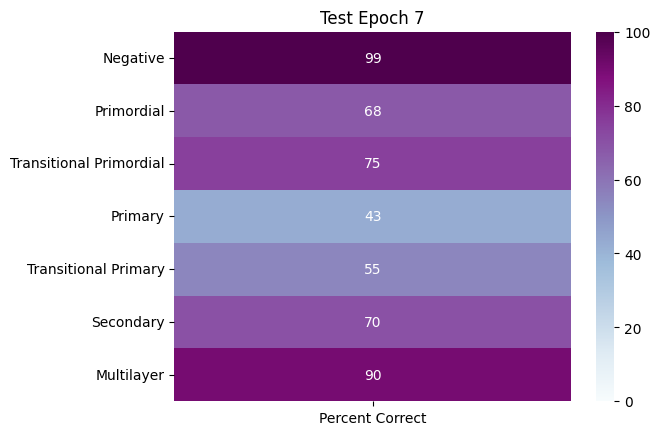

```
  Primordial:
    76.2% at Epoch 1
    Full Epoch: ['97.0%', '76.2%', '57.4%', '63.3%', '52.4%', '69.8%', '93.8%']
```

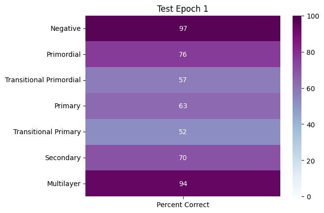

```
  Transitional Primordial:
    85.8% at Epoch 16
    Full Epoch: ['99.2%', '46.4%', '85.8%', '37.8%', '56.2%', '63.8%', '90.2%']
```

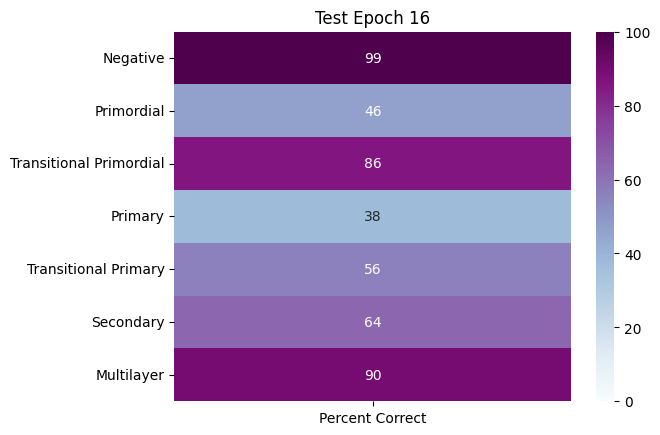

```
  Primary:
    63.3% at Epoch 1
    Full Epoch: ['97.0%', '76.2%', '57.4%', '63.3%', '52.4%', '69.8%', '93.8%']
```

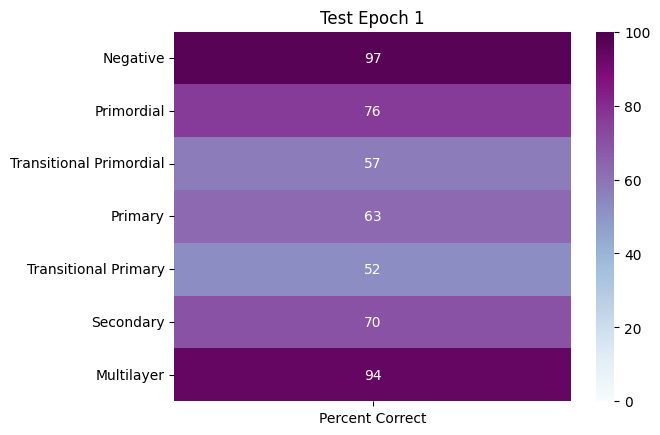

```
  Transitional Primary:
    56.4% at Epoch 5
    Full Epoch: ['98.8%', '62.3%', '75.6%', '49.6%', '56.4%', '72.0%', '89.2%']
```

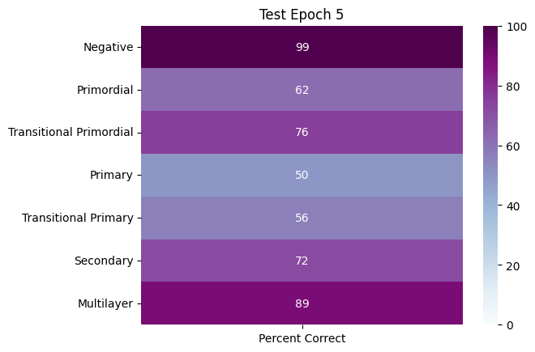

```
  Secondary:
    85.3% at Epoch 22
    Full Epoch: ['98.8%', '75.5%', '65.6%', '41.6%', '52.0%', '85.3%', '85.1%']
```

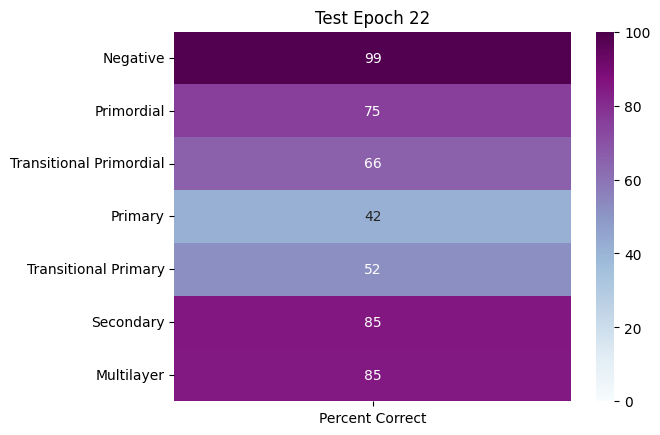

```
  Multilayer:
    94.4% at Epoch 15
    Full Epoch: ['98.5%', '34.0%', '84.3%', '55.4%', '48.0%', '63.0%', '94.4%']
```

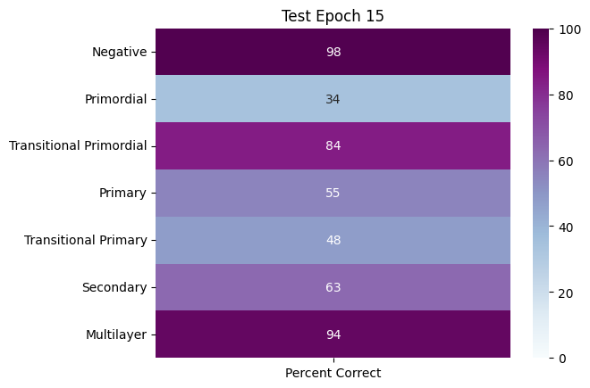

```
Validate:
  Negative:
    99.5% at Epoch 7
    Full Epoch: ['99.5%', '71.1%', '75.2%', '73.8%', '67.5%', '70.4%', '93.5%']
```

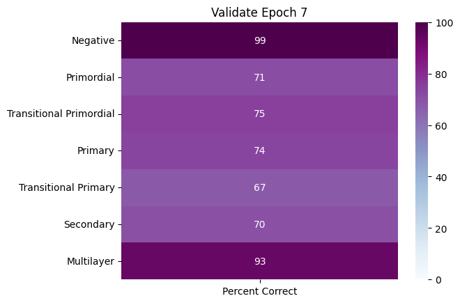

```
  Primordial:
    77.0% at Epoch 22
    Full Epoch: ['99.2%', '77.0%', '64.5%', '71.4%', '62.0%', '83.8%', '81.4%']
```

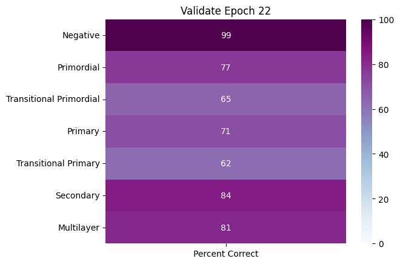

```
  Transitional Primordial:
    87.6% at Epoch 16
    Full Epoch: ['99.4%', '50.4%', '87.6%', '74.5%', '69.4%', '79.2%', '90.6%']
```

[5 more figures not shown]

```python
#Plot the accuracies for all follicle classes for each epoch that had the highest accuracy for each follicle class
print("Highest Accuracies for Each Class per Phase\n")

for phase in phases:
    print("{}:".format(phase.capitalize()))

    for label in classes:
        class_percentages = per_class_accuracies[phase][label]
        max_class_percentage = np.max(class_percentages)
        max_epoch = class_percentages.index(max_class_percentage)

        print("  {}:\n    {:.1f}% at Epoch {}".format(label, max_class_percentage, max_epoch))

        best_epoch_percentages = []

        for key in classes:
            best_epoch_percentages.append(per_class_accuracies[phase][key][max_epoch])

        print("    Full Epoch: {}".format(["{:.1f}%".format(i) for i in best_epoch_percentages]))

        _, ax = plt.subplots()

        sns.heatmap(np.array(best_epoch_percentages).reshape(-1, 1), vmin = 0, vmax = 100, cmap = 'BuPu', annot = True)

        ax.set_title("{} Epoch {}".format(phase.capitalize(), max_epoch))
        ax.set_yticklabels(classes, rotation = 0)
        ax.set_xticklabels(["Percent Correct"])

        if save_figs:
            file = phase.capitalize() + "_Epoch_" + str(max_epoch) + "_Percent_Correct_Heatmap.png"
            plt.savefig(INPUT_DIR + OUTPUT_DIR + file)

        plt.show()

    print()
```

Create and save a plot of every follicle class accuracy for the epochs that had the best loss score and overall accuracy score.

```
All Accuracies per Phase for Best Accuracy and Loss Epochs

Best Accuracy Epoch: 24
  Train: ['99.2%', '99.9%', '99.2%', '100.0%', '100.0%', '100.0%', '100.0%']
```

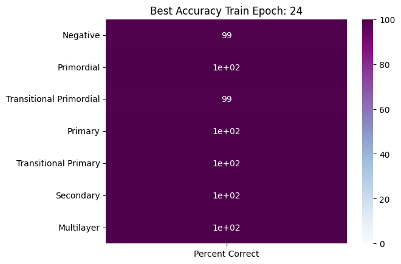

```
  Test: ['98.8%', '67.2%', '73.1%', '43.9%', '48.9%', '71.2%', '90.5%']
```

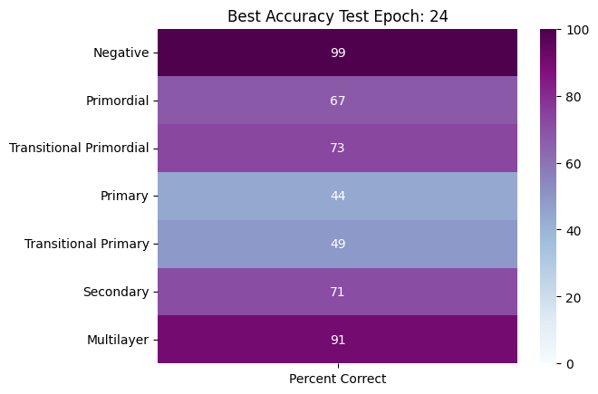

```
  Validate: ['99.2%', '69.6%', '73.0%', '80.4%', '56.4%', '77.5%', '92.4%']
```

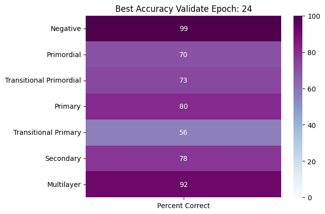

```
Best Loss Epoch: 1
  Train: ['97.2%', '77.6%', '58.9%', '95.3%', '94.9%', '99.5%', '99.7%']
```

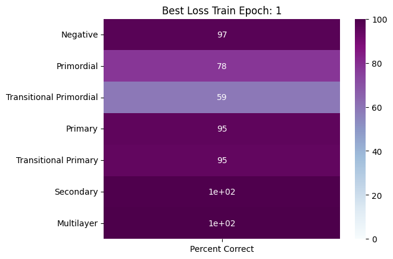

```
  Test: ['97.0%', '76.2%', '57.4%', '63.3%', '52.4%', '69.8%', '93.8%']
```

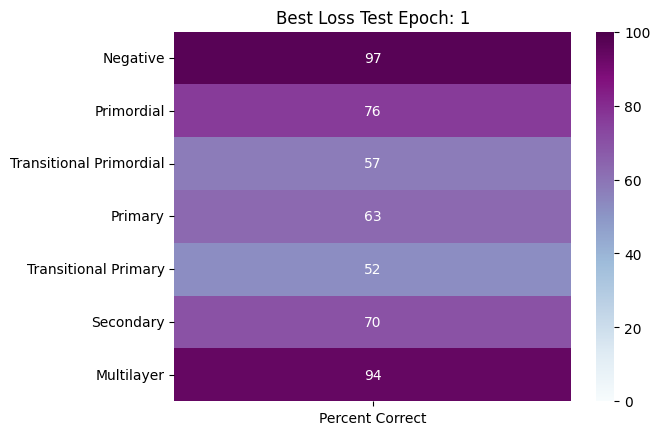

```
  Validate: ['97.8%', '71.6%', '55.6%', '82.8%', '68.4%', '65.4%', '92.3%']
```

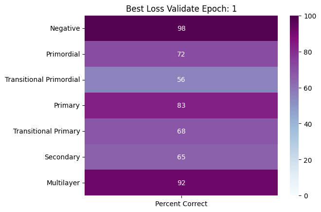

```python
#Plot the accuracies for each follicle class for the best accuracy and loss epochs
print("All Accuracies per Phase for Best Accuracy and Loss Epochs\n")

for epoch, criteria in zip([best_accuracy_epoch, best_loss_epoch], ['accuracy', 'loss']):
    print("Best {} Epoch: {}".format(criteria.capitalize(), epoch))

    for phase in phases:
        best_epoch_percentages = []

        for label in classes:
            best_epoch_percentages.append(per_class_accuracies[phase][label][epoch])

        print("  {}: {}".format(phase.capitalize(), ["{:.1f}%".format(i) for i in best_epoch_percentages]))

        _, ax = plt.subplots()

        sns.heatmap(np.array(best_epoch_percentages).reshape(-1, 1), vmin = 0, vmax = 100, cmap = 'BuPu', annot = True)

        ax.set_title("Best {} {} Epoch: {}".format(criteria.capitalize(), phase.capitalize(), epoch))
        ax.set_yticklabels(classes, rotation = 0)
        ax.set_xticklabels(["Percent Correct"])

        if save_figs:
            file = phase.capitalize() + "_Epoch_" + str(epoch) + "_Percent_Correct_Heatmap.png"
            plt.savefig(INPUT_DIR + OUTPUT_DIR + file)

        plt.show()

    print()
```

### Convert Notebook to HTML and Move to Output Directory / Clean Up Working Directory

Programmatically save the notebook, convert it to html, move the html file to the output directory, and copy the notebook to the output directory.

```python
#Create the output directory
make_output_dir()

#Needed for the next command to work, for some reason
time.sleep(1)

#Programmatically save the notebook
APP.commands.execute("docmanager:save")

#Convert the notebook to html
!jupyter nbconvert --to html "$NOTEBOOK_NAME"

#Move the html file and copy the notebook to the output directory
shutil.move(NOTEBOOK_NAME[:-6] + ".html", INPUT_DIR + OUTPUT_DIR + NOTEBOOK_NAME[:-6] + "_" + datetime.datetime.now().strftime("%Y-%m-%d_%H-%M-%S") + ".html")
shutil.copy2(NOTEBOOK_NAME, INPUT_DIR + OUTPUT_DIR)
```